# Template for generating books using Pandoc

M. M. Cheems

Abstract

A short commentary on the Markdown template for reports and books that can be compiled to HTML, EPUB and PDF using the [Pandoc](https://pandoc.org) universal text converter.

# 1 Introduction

#### Quickstart:

- `$ make` — to produce HTML;
- `$ make demo.epub` — to produce EPUB;
- `$ make demo.pdf` — to produce PDF;
- `$ make all` — to produce all three outputs.

#### Additional requirements besides Pandoc:

- pandoc-crossref, filter for numbering and cross-referencing figures, tables and equations;
- citeproc, extension for bibliography generation;
- For PDF generation:
  - a LaTeX system with XeTeX engine;
  - [Liberation fonts](https://github.com/liberationfonts/liberation-fonts/);
  - [DejaVu fonts](https://dejavu-fonts.github.io/).

## 1.1 Document metadata

All document metadata (title, author, etc.) together with style and localization are specified through the YAML file — `demo.yaml`. Some options are only relevant for PDF generated via XeLaTeX backend (“`fontsize`”, “`papersize`”, the whole “`header-includes`” block), others have impact on the resulting document regardless of format. See comments in the file.

## 1.2 Citations

Bibliographical sources are listed in the example of bibliography database (`demo.bib`) in BibTeX format. Citations and bibliography list are produced via citeproc extension library. The document uses American Physical Society citation style which is specified through a [CSL](https://docs.citationstyles.org/) file [american-physics-society.csl](https://www.zotero.org/styles/american-physics-society) (see “`FILTERS`” line in `settings.mk`). You may want to try some other styles listed [here](https://www.zotero.org/styles).

There are a few quirks when using a BibTeX database with citeproc due to certain limitations of CSL, see comments in `demo.bib`. Citations are produced by inserting source labels “`[@src_label]`”, like this: [1]. Several sources can be cited with “`[@src_label1; @src_label2; @src_label3]`”, see [2–4].

> **Note** that sources here are separated by “semicolon”, not by “comma” like in your LaTeX!

Earlier it was possible to refer to a particular page in a source with “`[@src_tag, pp. 4]`”, but now it seems to be opted out.

## 1.3 Inserting and cross-referencing figures, formulas and tables

Numbering and cross-referencing is done via pandoc-crossref filter, see “`FILTERS`” line in `settings.mk`.

### 1.3.1 Figures

Figures are inserted with a standard Pandoc syntax, image scale is specified inside curly brackets together with figure label:

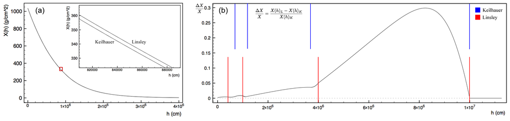

```markdown
![Figure caption](path-to image){ width=98% #fig:1 }
```

> **Note** that image scale specification must be space-separated from opening and closing brackets, though a figure label by itself does not need that.

The “`#fig:`” is a part of the figure label syntax and is mandatory. In-text reference to a figure is produced by inserting its label as “`[@fig:1]`”. The result is — see Fig. 1. The “Fig. ” part in the resulting reference (*figure prefix*) is controlled via “`figPrefix`” parameter in `demo.yaml` and is generated automatically.

### 1.3.2 Formulas

Formulas are inserted as a block of LaTeX math environment enclosed in “`$$..$$`” operator brackets:

```latex
$$
    E^2 = p^2 c^2 + m_0^2 c^4\text{.}
$$ {#eq:energy}
```

$$E^2 = p^2 c^2 + m_0^2 c^4\text{.}
\qquad{(1)}$$

Equation labels are specified inside curly brackets after a space from the closing “`$$`”. The “`#eq:`” is a part of the equation label syntax. In-text reference to equation is produced by inserting its label as “`([-@eq:energy])`”: behold the reference to equation (1).

> **Note** the “minus” character before “at” sign in the reference code: it suppresses insertion of *equation prefix* (“`eqnPrefix`” which is set to “`eq.` ” by default); i.e. without this minus the resulting reference would look like “(eq. 1)” rather than just “(1)”.

Pandoc can covert TeX-math to codes intended for several math rendering engines, most prominent of them are [MathJax](https://www.mathjax.org/) and [MathML](https://www.w3.org/TR/MathML/). Most web-browsers support both, but your average epub-reader supports only MathML. Thus, when converting to EPUB, the “`--mathml`” option is *always* recommended. This is also the default option for HTML conversion and it can be changed to other value (see “`HTML_MATH`” line in `settings.mk`):

```
$ make HTML_MATH=--mathjax
```

This will produce a HTML document that renders equations via MathJax.

> **Another consideration** when choosing a math rendering option: a web-page that displays MathML is completely self-contained, while MathJax by default relies heavily on external web.

### 1.3.3 Tables

A detailed description of syntaxes for tables of various types is given in [6], section [8.9](https://pandoc.org/chunkedhtml-demo/8.9-tables.html). Here we use the *pipe table* syntax:

```markdown
| Right | Left | Default | Center |
|------:|:-----|---------|:------:|
|   12  |  12  |    12   |    12  |
|  123  |  123 |   123   |   123  |
|    1  |    1 |     1   |     1  |

 : Demonstration of pipe table syntax, example
   [8.9.5](https://pandoc.org/chunkedhtml-demo/8.9-tables.html)
   by MacFarlane\ [@Pandoc]. {#tbl:table_example}
```

Table 1: Demonstration of pipe table syntax, example [8.9.5](https://pandoc.org/chunkedhtml-demo/8.9-tables.html) by MacFarlane [6].

| Right | Left | Default | Center |
| --- | --- | --- | --- |
| 12 | 12 | 12 | 12 |
| 123 | 123 | 123 | 123 |
| 1 | 1 | 1 | 1 |

A table can be referenced by inserting its tag: “`[@tbl:table_example]`”. The “`#tbl:`” is a part of the table label syntax. The result: the beauty of a pipe table is demonstrated in Table 1. The “Table ” part of the reference (*table prefix*) is produced automatically and is controlled via “`tblPrefix`” parameter in `demo.yaml`.

## 1.4 I18n

Language settings are specified in the document metadata file (see `demo.yaml` and `demo-ru.yaml`). The `demo-ru.yaml` provides the example for Russian language. To switch to a different YAML file, edit the “`YAML`” line in the `settings.mk`:

```
YAML           =    $(DOC)-ru.yaml
```

or specify it in the command line:

```
make all YAML=demo-ru.yaml
```

> **Note** that unlike some BibTeX-based citation styles, the “citeproc + CSL” filter does not support the “`language`” field type for individual bibliographical records; this leads to funny glithes in the rendered citations of English sources as shown in Fig. 2.

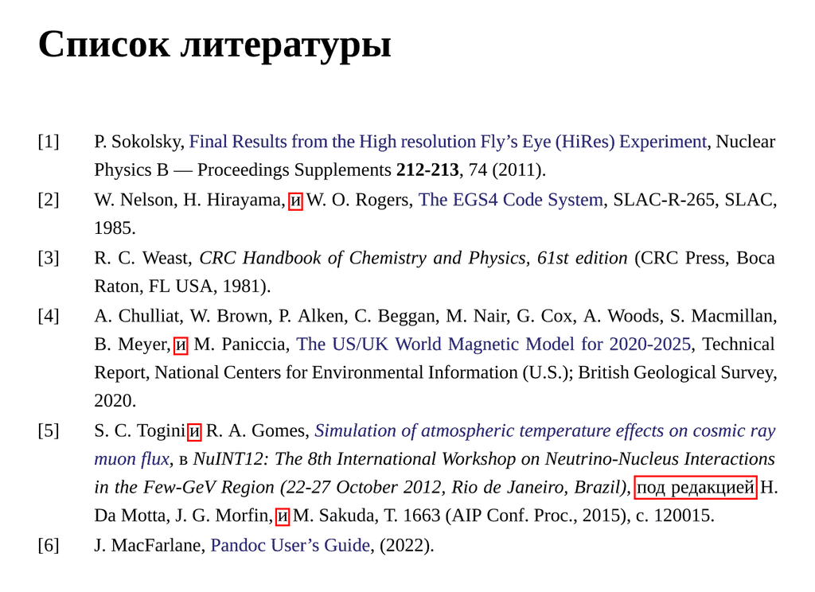

Fig. 2: The bibliography list rendered by citeproc filter in cyrillic language environment. Note cyrillic insertions in resulting English citations.

# References

[1]

P. Sokolsky, [Final results from the high resolution fly’s eye (HiRes) experiment](https://doi.org/10.1016/j.nuclphysbps.2011.03.010), Nuclear Physics B — Proceedings Supplements **212-213**, 74 (2011).

[2]

W. Nelson, H. Hirayama, and W. O. Rogers, [The EGS4 Code System](https://www-public.slac.stanford.edu/scidoc/docMeta.aspx?slacPubNumber=slac-R-265), SLAC-R-265, SLAC, 1985.

[3]

R. C. Weast, *CRC Handbook of Chemistry and Physics, 61st edition* (CRC Press, Boca Raton, FL USA, 1981).

[4]

A. Chulliat, W. Brown, P. Alken, C. Beggan, M. Nair, G. Cox, A. Woods, S. Macmillan, B. Meyer, and M. Paniccia, [The US/UK World Magnetic Model for 2020-2025](https://doi.org/10.25923/ytk1-yx35), Technical Report, National Centers for Environmental Information (U.S.); British Geological Survey, 2020.

[5]

S. C. Togini and R. A. Gomes, *[Simulation of atmospheric temperature effects on cosmic ray muon flux](https://doi.org/10.1063/1.4919521)*, in *NuINT12: The 8th International Workshop on Neutrino-Nucleus Interactions in the Few-GeV Region (22-27 October 2012, Rio de Janeiro, Brazil)*, edited by H. Da Motta, J. G. Morfin, and M. Sakuda, Vol. 1663 (AIP Conf. Proc., 2015), p. 120015.

[6]

J. MacFarlane, [Pandoc user’s guide](https://pandoc.org/chunkedhtml-demo/), (2022).